# What type of exercise?. Machine Learning Predictions

Carlos Ortega

August 25th, 2015

# 1 Synopsis

1. Six different persons performed five type of exercices.
2. They monitored their activity with a wearable device.
3. All data collected is available in a file **pml_training.csv**
- Within this file, each row represents a type of exercise performed in a particular date.
- Each row consists of many different columns with the data collected with the wearable device.
4. Based on this file, the goal is create a model capable of predicting with type of exercise was performed for each of the 20 cases (rows) included in file **pml_testing.csv**.

# 2 Model building strategy

## 2.1 Data munging

When building a machine learning model the first activity, the most time consuming one, is to clean, prepare the data before applying a statistical model.

In the file provided, data is quite well organized. The main obstacle comes from how to deal with so many different variables. The typical questions we should aks ourselves are:

- Are all of them valid, in the sense that they do not include too many missing values?
- Even if the variables have adequate values, are they meaningful for the purpose of the analysis?.
- Or even if they have values, are all of them equal?
- And in terms of simplification (to build a parsimonious model), can we ignore some of the variables because they are correlated with some others? Are they superfluos?

In the assignment I have considered all these issues:

- The original data is data.frame of **19622 rows** and **160** columns.
- By using **caret** functions **nearZeroVar()** and **findCorrelation()** and ad-hoc developed function to count the number of NAs by column, the number of variables were reduced up to __45_-.
- two additional columns with date/hour information were also ignored as well as the one with the name of the persons who performed the exercises.
- So finally the dataset was reduced to **42** columns, all of them numeric, except the one with the type of exercise (**classe**), the predictor.

This process was laborious and very time consuming compared with model building, but it is key to avoid problems when applying the different model algorithms.

## 2.2 Model selection

With function **createDataPartition()** I divided the dataset in two groups **training** (with the 70% of the cases) and **testing** (with the remaining 30%).

Although the prediction was performed based on a particular model, I explored several different machine learning techniques. The selection of these different techniques were based on different criteris: easiness of use and interpretation, well-known good performance with classification problems and also, their execution time: 1. Regression and Classification Trees, based on **rpart** library. 2. Partial Least Squares, based on **pls** library. 3. Functional Discriminant Analysis, based on **fda** library. 3. A more improved kind of trees partitioning classification technique based on **C5.0** library. 4. And a more recent and improved version of the Generalized Boosting Modeling (**gbm**) algorithm, Extreme Generalized Boosting Modeling (*xgboost* library).

Note: The last two techniques are **bagged** algorithms.

To avoid **out of sample error** I applied a **cross validated** (**K=10** and 5 times) for each model, which is specified in the **trainControl** parameters.

With the function, **resamples()** (also in **caret** library) is possible to get a plot with a comparison of the different values of **Accuracy** (95% CI) for all the models evaluated. Each of the models need to be stored in the workspace.

This is the plot for the five models evaluated:

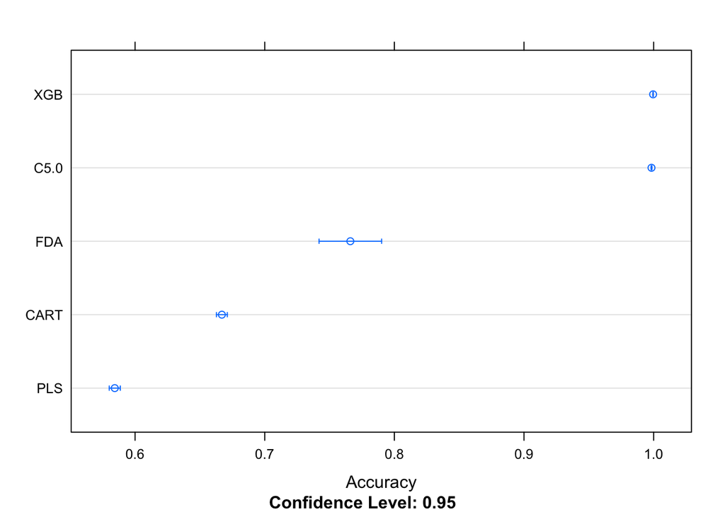

As it can be seen in the graph, models based on **C5.0** and **xgb** got an Accuracy of **99%** which is quite impresive, compared with the results that *rpart*, *pls* and *fda* achieved.

These models took around two hours of execution (on a MacBook Pro 4 with 8Gb of RAM and 4 cores). In terms of execution, the parallel capabilities that *caret* supports were used.

# 3 Results

Regarding the winner model, this is the **R** code used:

```r
set.seed(1)
cvCtrl <- trainControl(method = "repeatedcv", repeats = 5,
                       classProbs = TRUE,
                       verboseIter = TRUE)

#Model
modFitxgb <- train(
  classe ~ ., data = trainDat,
  method = "xgbTree",
  preProc = c("center", "scale"),
  tuneLength = 10,
  metric = "Accuracy",
  trControl = cvCtrl
)
```

With this model, the **confusionMatrix()** and the **varImp()** (variable importance) are executed in this way, getting the following results:

```r
#Prediction
predxgb <- predict(modFitxgb, testDat)
#ConfusionMatrix
conMat <- confusionMatrix(predxgb, testDat$classe)
conMat
```

```
## Confusion Matrix and Statistics
##
##           Reference
## Prediction    A    B    C    D    E
##          A 1674    1    0    0    0
##          B    0 1138    0    0    0
##          C    0    0 1026    0    0
##          D    0    0    0  963    2
##          E    0    0    0    1 1080
##
## Overall Statistics
##
##                Accuracy : 0.9993
##                  95% CI : (0.9983, 0.9998)
##     No Information Rate : 0.2845
##     P-Value [Acc > NIR] : < 2.2e-16
##
##                   Kappa : 0.9991
##  Mcnemar's Test P-Value : NA
##
## Statistics by Class:
##
##                      Class: A Class: B Class: C Class: D Class: E
## Sensitivity            1.0000   0.9991   1.0000   0.9990   0.9982
## Specificity            0.9998   1.0000   1.0000   0.9996   0.9998
## Pos Pred Value         0.9994   1.0000   1.0000   0.9979   0.9991
## Neg Pred Value         1.0000   0.9998   1.0000   0.9998   0.9996
## Prevalence             0.2845   0.1935   0.1743   0.1638   0.1839
## Detection Rate         0.2845   0.1934   0.1743   0.1636   0.1835
## Detection Prevalence   0.2846   0.1934   0.1743   0.1640   0.1837
## Balanced Accuracy      0.9999   0.9996   1.0000   0.9993   0.9990
```

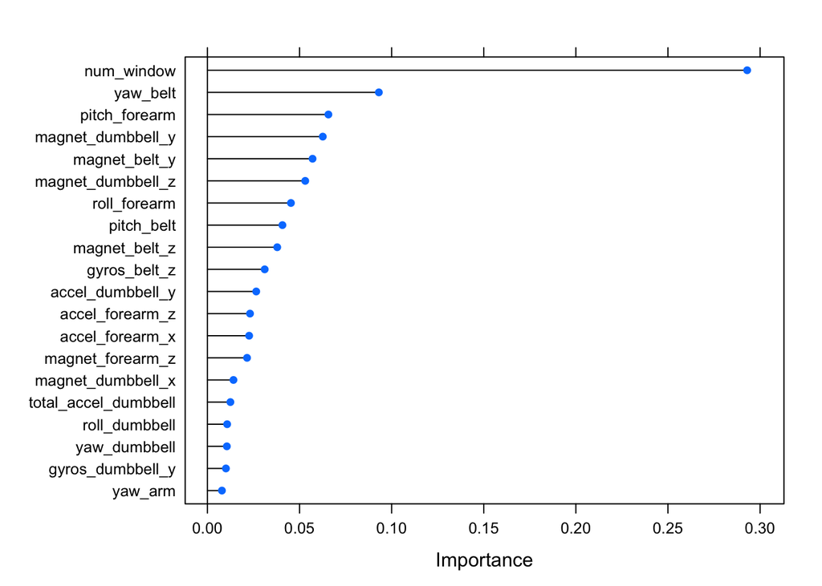

```r
#Variable Importance
Impxgb <- varImp( modFitxgb, scale=F)
plot(Impxgb, top=20)
```

# 4 Conclusions